# 02 Playing With Access Tokens

```python
clientIDFile = open("clientID.txt", "r")
for line in clientIDFile:
    clientID = line.strip()

clientSecretFile = open("clientSecret.txt", "r")
for line in clientSecretFile:
    clientSecret = line.strip()
```

[figure not shown]

```python
# I did not write the code to get the access token
# Found in https://stackoverflow.com/questions/61179753/is-there-a-python-script-to-generate-blizzard-api-access-token

import requests

def create_access_token(client_id, client_secret, region = 'us'):
    data = { 'grant_type': 'client_credentials' }
    response = requests.post('https://%s.battle.net/oauth/token' % region, data=data, auth=(client_id, client_secret))
    return response.json()

response = create_access_token(clientID, clientSecret)
print(response)
```

```
{'access_token': 'USzVwXQlUg7qpDT2PpIs3JtQiy8hOFRcmE', 'token_type': 'bearer', 'expires_in': 86399}
```

```python
response['access_token']
```

```
'USzVwXQlUg7qpDT2PpIs3JtQiy8hOFRcmE'
```

Success!

Will clean this up later to do a try/catch...

```python
# Grabbed the game URLs from part 1 where I was playing with the develop.battle.net documentation

itemUrl = 'https://us.api.blizzard.com/data/wow/item/172231?namespace=static-us&locale=en_US&access_token='

auctionUrl = 'https://us.api.blizzard.com/data/wow/connected-realm/3684/auctions?namespace=dynamic-us&locale=en_US&access_token='

auctionResults = requests.get(auctionUrl + response['access_token'])
```

```python
requests.get(auctionUrl + response['access_token'])
```

```
<Response [200]>
```

Played around with the item table because the data size was smaller.

```python
itemResults = requests.get(itemUrl + response['access_token'])
```

```python
itemResults.text
```

```
'{"_links":{"self":{"href":"https://us.api.blizzard.com/data/wow/item/172231?namespace=static-9.0.2_36532-us"}},"id":172231,"name":"Sacred Shard","quality":{"type":"RARE","name":"Rare"},"level":1,"required_level":0,"media":{"key":{"href":"https://us.api.blizzard.com/data/wow/media/item/172231?namesp…
```

```python
# https://www.w3schools.com/python/python_json.asp

# Needed to clean up the results

import json

itemCleaned = json.loads(itemResults.text)

itemCleaned
```

```
{'_links': {'self': {'href': 'https://us.api.blizzard.com/data/wow/item/172231?namespace=static-9.0.2_36532-us'}},
 'id': 172231,
 'inventory_type': {'name': 'Non-equippable', 'type': 'NON_EQUIP'},
 'is_equippable': False,
 'is_stackable': True,
 'item_class': {'id': 7,
  'key': {'href': 'https://us.api.blizzard.com/data/wow/item-class/7?namespace=static-9.0.2_36532-us'},
  'name': 'Tradeskill'},
 'item_subclass': {'id': 12,
  'key': {'href': 'https://us.api.blizzard.com/data/wow/item-class/7/item-subclass/12?namespace=static-9.0.2_36532-us'},
  'name': 'Enchanting'},
 'level': 1,
 'max_count': 0,
 'media': {'id': 172231,
  'key': {'href': 'https://us.api.blizzard.com/data/wow/media/item/172231?namespace=static-9.0.2_36532-us'}},
 'name': 'Sacred Shard',
 'preview_item': {'crafting_reagent': 'Crafting Reagent',
  'inventory_type': {'name': 'Non-equippable', 'type': 'NON_EQUIP'},
  'is_subclass_hidden': True,
  'item': {'id': 172231,
   'key': {'href': 'https://us.api.blizzard.com/data/wow/item/172231?namespace=static-9.0.2_36532-us'}},
  'item_class': {'id': 7,
   'key': {'href': 'https://us.api.blizzard.com/data/wow/item-class/7?namespace=static-9.0.2_36532-us'},
   'name': 'Tradeskill'},
  'item_subclass': {'id': 12,
   'key': {'href': 'https://us.api.blizzard.com/data/wow/item-class/7/item-subclass/12?namespace=static-9.0.2_36532-us'},
   'name': 'Enchanting'},
  'media': {'id': 172231,
   'key': {'href': 'https://us.api.blizzard.com/data/wow/media/item/172231?namespace=static-9.0.2_36532-us'}},
  'name': 'Sacred Shard',
  'quality': {'name': 'Rare', 'type': 'RARE'}},
 'purchase_price': 0,
 'purchase_quantity': 3,
 'quality': {'name': 'Rare', 'type': 'RARE'},
 'required_level': 0,
 'sell_price': 0}
```

Checked to see if I could validate the results. Looked for the item name.

```python
itemCleaned['name']
```

```
'Sacred Shard'
```

Success!

Now for the hard part... Auction data!

```python
# List to filter items in our results...

import datetime

itemList = [172231]
```

```python
auctionCleaned = json.loads(auctionResults.text)

auctionCleaned['auctions']
```

[output not shown]

[output cut: 6233 more lines]

[output not shown]

Closer, but still not the results I'm looking for. I want to narrow down based on the itemID and get the results for those specific auctions...

```python
auctionList = auctionCleaned['auctions']
```

```python
auctionList
```

[output not shown]

[output cut: 6233 more lines]

[output not shown]

Looking to see how to break down the itemID. This is going to be used to filter the results...

```python
auctionList[0]['item']['id']
```

```
173130
```

```python
currentDatetime = datetime.datetime.now()

currentDate = currentDatetime.strftime("%x")
currentTime = currentDatetime.strftime("%X")
```

[output not shown]

```python
auctionByRow = []

for row in auctionList:
    if row['item']['id'] in itemList:
        auctionByRow.append((row['id'], row['item']['id'], row['quantity'], row['unit_price'], currentDate, currentTime))
    else: ''
```

```python
auctionByRow
```

```
[(2084251649, 172231, 17, 758900, '01/26/21', '10:43:05'),
 (2084262660, 172231, 15, 1498900, '01/26/21', '10:43:05'),
 (2084312331, 172231, 4, 758900, '01/26/21', '10:43:05'),
 (2084312760, 172231, 4, 758900, '01/26/21', '10:43:05'),
 (2084314801, 172231, 5, 755000, '01/26/21', '10:43:05'),
 (2084341238, 172231, 3, 800000, '01/26/21', '10:43:05'),
 (2084351311, 172231, 11, 755000, '01/26/21', '10:43:05'),
 (2084351554, 172231, 25, 789500, '01/26/21', '10:43:05'),
 (2084357460, 172231, 26, 755000, '01/26/21', '10:43:05'),
 (2084438603, 172231, 7, 799900, '01/26/21', '10:43:05'),
 (2084705501, 172231, 5, 810000, '01/26/21', '10:43:05'),
 (2085293729, 172231, 13, 1238000, '01/26/21', '10:43:05'),
 (2085295872, 172231, 50, 1238000, '01/26/21', '10:43:05'),
 (2085353585, 172231, 2, 855100, '01/26/21', '10:43:05'),
 (2085363165, 172231, 2, 855100, '01/26/21', '10:43:05'),
 (2085440655, 172231, 1, 755000, '01/26/21', '10:43:05'),
 (2085440753, 172231, 6, 755000, '01/26/21', '10:43:05'),
 (2085442701, 172231, 5, 755000, '01/26/21', '10:43:05'),
 (2085444491, 172231, 1, 755000, '01/26/21', '10:43:05'),
 (2085452681, 172231, 3, 789500, '01/26/21', '10:43:05'),
 (2085469926, 172231, 7, 754900, '01/26/21', '10:43:05'),
 (2085471449, 172231, 6, 754900, '01/26/21', '10:43:05'),
 (2085479813, 172231, 2, 754900, '01/26/21', '10:43:05'),
 (2085487484, 172231, 5, 754900, '01/26/21', '10:43:05'),
 (2085487721, 172231, 21, 754900, '01/26/21', '10:43:05'),
 (2085487752, 172231, 36, 754900, '01/26/21', '10:43:05'),
 (2085522774, 172231, 800, 1500000, '01/26/21', '10:43:05'),
 (2085531867, 172231, 8, 754900, '01/26/21', '10:43:05'),
 (2085531906, 172231, 1, 754900, '01/26/21', '10:43:05'),
 (2085533730, 172231, 7, 754900, '01/26/21', '10:43:05'),
 (2085540468, 172231, 20, 754900, '01/26/21', '10:43:05'),
 (2085543126, 172231, 17, 754900, '01/26/21', '10:43:05'),
 (2085546035, 172231, 1, 754900, '01/26/21', '10:43:05'),
 (2085546169, 172231, 5, 754900, '01/26/21', '10:43:05'),
 (2085548043, 172231, 10, 754900, '01/26/21', '10:43:05'),
 (2085549999, 172231, 5, 754900, '01/26/21', '10:43:05'),
 (2085590595, 172231, 4, 754900, '01/26/21', '10:43:05'),
 (2085590929, 172231, 1, 754900, '01/26/21', '10:43:05'),
 (2085590959, 172231, 5, 744900, '01/26/21', '10:43:05'),
 (2085595521, 172231, 10, 744900, '01/26/21', '10:43:05'),
```

[output cut: 84 more lines]

```
 (2086365321, 172231, 20, 29990000, '01/26/21', '10:43:05'),
 (2086365695, 172231, 8, 700000, '01/26/21', '10:43:05'),
 (2086368797, 172231, 4, 700000, '01/26/21', '10:43:05'),
 (2086370735, 172231, 7, 700000, '01/26/21', '10:43:05'),
 (2086370940, 172231, 4, 700000, '01/26/21', '10:43:05'),
 (2086370960, 172231, 4, 700000, '01/26/21', '10:43:05'),
 (2086371659, 172231, 67, 1775900, '01/26/21', '10:43:05'),
 (2086374174, 172231, 21, 700000, '01/26/21', '10:43:05'),
 (2086376731, 172231, 11, 700000, '01/26/21', '10:43:05'),
 (2086379039, 172231, 1, 700000, '01/26/21', '10:43:05'),
 (2086379185, 172231, 4, 700000, '01/26/21', '10:43:05'),
 (2086379333, 172231, 62, 700000, '01/26/21', '10:43:05'),
 (2086382607, 172231, 1, 700000, '01/26/21', '10:43:05'),
 (2086382781, 172231, 6, 700000, '01/26/21', '10:43:05'),
 (2086384979, 172231, 4, 700000, '01/26/21', '10:43:05')]
```

Success! Every auction for Sacred Shards. I added in a date and time for later use. Will be trying to find the best date/time to buy/sell items. The first column is the auctionID, second is the itemID, third is the quantity, fourth is the unit price, fifth is date the auction was found, sixth was time auction was found. I might need to narrow the auction postings to "short" durations later. Long duration postings might cause outliers.

I asked my guild what items have high volitility. These items should have the best potential for profit because of the range they can sell in:

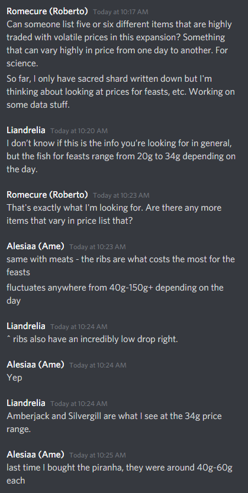

There were two feasts, but only one of them used ribs and piranha:

[figure not shown]

Looked up the item in the documentation:

[figure not shown]

Looked up the non-vendor components for the feasts and the feast itself:

Feast of Gluttonous Hedonism - 172043

Tenebrous Ribs - 172053 Phantasmal Haunch - 172055

Silvergill Pike - 173034 Spinefin Piranha - 173036 Elysian Thade - 173037

These are the items I'm going to be playing with.